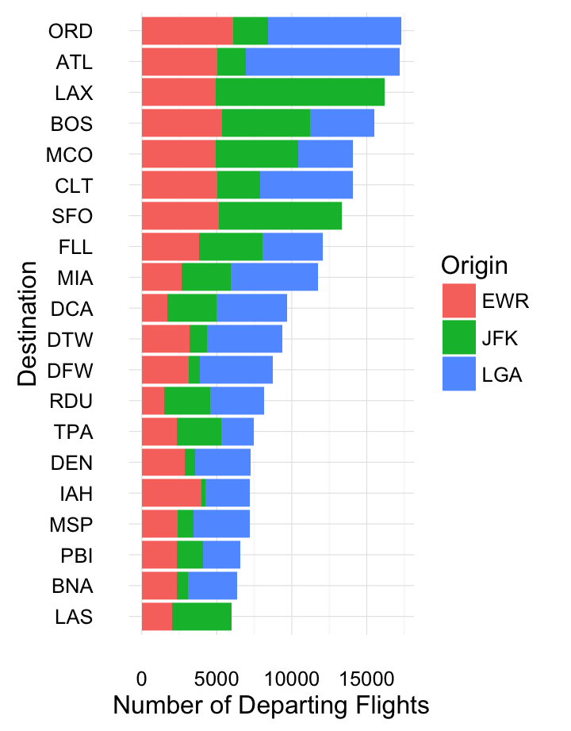

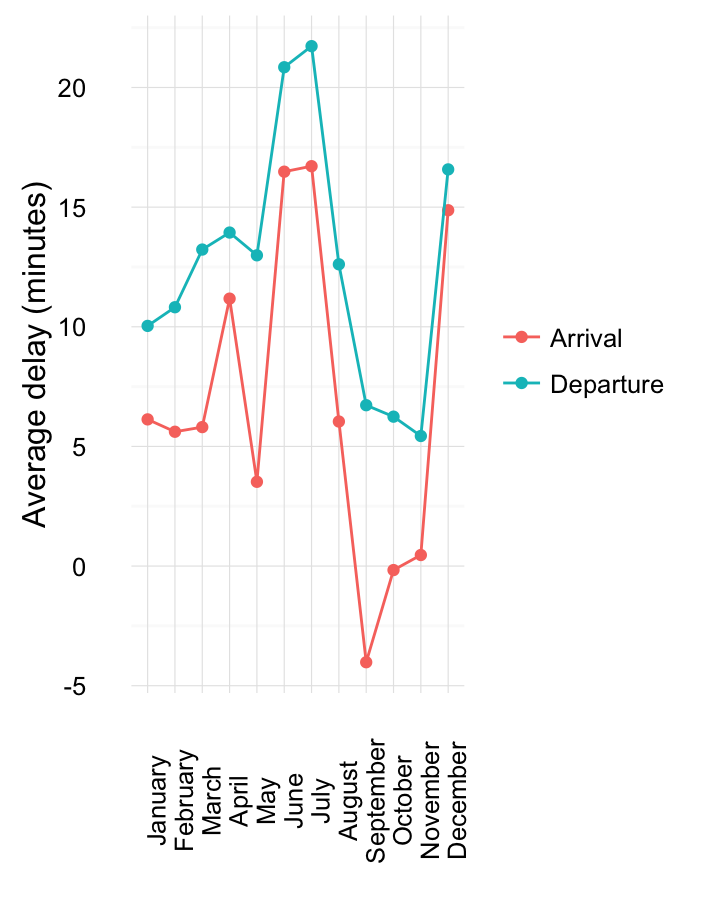

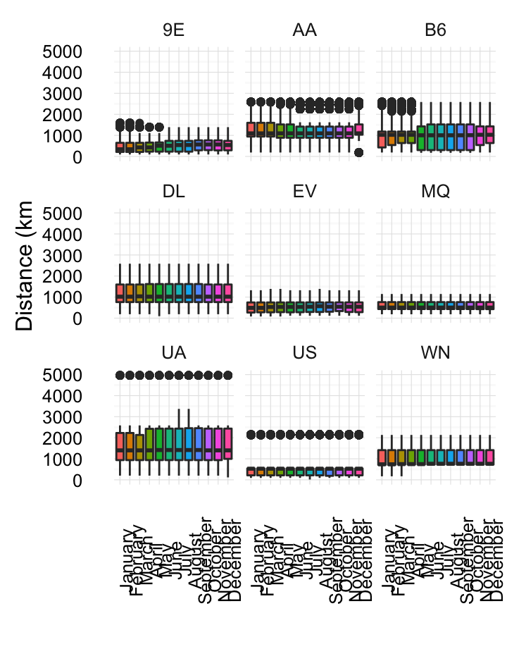

# Overview

### Top Destinations

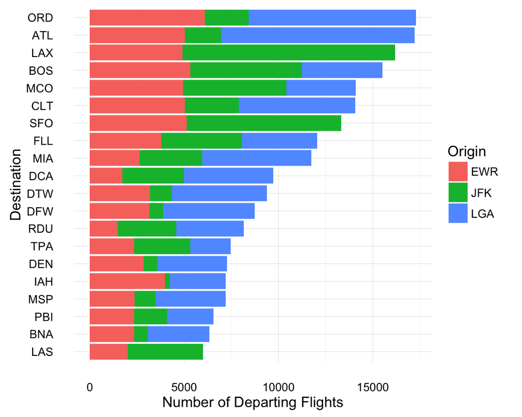

### Highest-Volume Carrier This Year

UA: 58,665 flights.

### Most On-Time Major Carrier This Year

AA: 0.4 min late

### Fun note!

The one subtlety is in transforming Destination into a “factor” variable with levels sorted by the number of flights to that destination. That operation is the standard way to **sort** your plots in ggplot2.

It’s instructive to step through the various lines of constructing the plot.

# Managing Delays

### Flights tend to be delayed most in the summer, suggesting that volume more than weather is the primary determinant of delays.

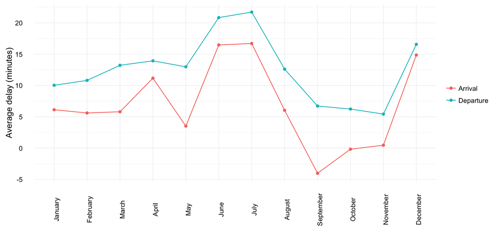

To make this chart, we first create a table in which each row is the average delay for a given month. Each month has two rows: one for departure delay and one for arrival delay.

You can add multiple geoms according to the same aesthetics. In this example, adding `geom_path()` with just `x` and `y` aesthetics specified turns out to be a “bad recipe”: we need to add an additional aesthetic `group` before the plot makes sense.

### Distance travelled is consistent over the course of the year, but varies substantially by carrier.

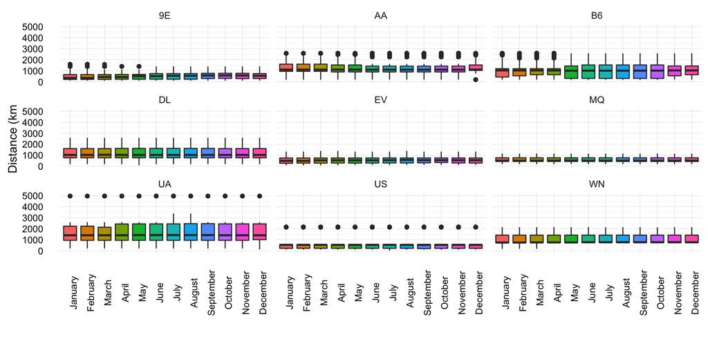

Boxplots are a nice way to visualize distributions, which are relevant when you care not just about the average but variation around that average.

Easy *faceting* is one of `ggplot2`’s killer features. With just one line, you can implement a “small multiples” visualization, in which the same kind of chart is repeated for different conditions of a categorical variable.